# THESIS PROJECT:AN OVERVIEW OF BLOOD PRESSURE RISK FACTORS

1. Loading and importing data from Excel into R

```r
Data<-read.csv("C:/Users/SSEKIRIWO ANDREW/Desktop/Diabetes/Diabetes data.csv")
```

2. An overview of the data

```r
names(Data)
```

```
[1] "patient"     "age"         "gender"      "sbp"         "weight"
[6] "height"      "smoking_sta" "family_his"
```

```r
nrow(Data)
```

```
[1] 93
```

```r
ncol(Data)
```

```
[1] 8
```

```r
head(Data,10)
```

|  | patient | age | gender | sbp | weight | height | smoking_sta | family_his |
| --- | --- | --- | --- | --- | --- | --- | --- | --- |
| 1 | 1 | 72 | m | 180 | 78 | 1.55 | 1 | 1 |
| 2 | 2 | 67 | f | 126 | 65 | 1.45 | 2 | 1 |
| 3 | 3 | 41 | f | 132 | NA | 1.67 | 2 | 1 |
| 4 | 4 | 77 | f | 150 | 67 | 1.62 | 2 | Don\x92t know |
| 5 | 5 | 63 | f | 146 | 55 | 1.70 | 2 | 1 |
| 6 | 6 | 42 | m | 160 | 67 | 1.78 | 2 | 2 |
| 7 | 7 | 59 | m | 162 | 68 | 1.65 | 2 | 2 |
| 8 | 8 | 62 | f | 156 | 67 | 1.45 | 2 | 2 |
| 9 | 9 | 65 | m | 170 | NA | 1.54 | 1 | 2 |
| 10 | 10 | 53 | m | 124 | 78 | 1.55 | 1 | NA |

```r
tail(Data,10)
```

|  | patient | age | gender | sbp | weight | height | smoking_sta | family_his |
| --- | --- | --- | --- | --- | --- | --- | --- | --- |
| 84 | 84 | 35 | f | 117 | 49 | 1.62 | 1 | 2 |
| 85 | 85 | 36 | f | 118 | 61 | 1.79 | 1 | 1 |
| 86 | 86 | 29 | m | 124 | 56 | 1.81 | 1 | 2 |
| 87 | 87 | 55 | m | 134 | 60 | 1.79 | 2 | 1 |
| 88 | 88 | 40 | m | 112 | 55 | 1.46 | 1 | 1 |
| 89 | 89 | 63 | f | 126 | 67 | 1.43 | 1 | 2 |
| 90 | 90 | 41 | m | 134 | 68 | 1.67 | 1 | 2 |
| 91 | 91 | 59 | f | 123 | 67 | 1.77 | 2 | 2 |
| 92 | 92 | 54 | f | 109 | 55 | 1.78 | 2 | 2 |
| 93 | 93 | 43 | m | 123 | NA | 1.75 | 1 | 1 |

```r
str(Data)
```

```
'data.frame':   93 obs. of  8 variables:
 $ patient    : int  1 2 3 4 5 6 7 8 9 10 ...
 $ age        : int  72 67 41 77 63 42 59 62 65 53 ...
 $ gender     : chr  "m" "f" "f" "f" ...
 $ sbp        : int  180 126 132 150 146 160 162 156 170 124 ...
 $ weight     : int  78 65 NA 67 55 67 68 67 NA 78 ...
 $ height     : num  1.55 1.45 1.67 1.62 1.7 1.78 1.65 1.45 1.54 1.55 ...
 $ smoking_sta: int  1 2 2 2 2 2 2 2 1 1 ...
 $ family_his : chr  "1" "1" "1" "Don\x92t know" ...
```

```r
summary(Data)
```

```
    patient        age           gender               sbp            weight
 Min.   : 1   Min.   :29.00   Length:93          Min.   :106.0   Min.   :46.00
 1st Qu.:24   1st Qu.:48.50   Class :character   1st Qu.:123.0   1st Qu.:58.00
 Median :47   Median :58.00   Mode  :character   Median :134.0   Median :65.00
 Mean   :47   Mean   :57.63                      Mean   :137.7   Mean   :64.79
 3rd Qu.:70   3rd Qu.:66.50                      3rd Qu.:154.0   3rd Qu.:68.00
 Max.   :93   Max.   :87.00                      Max.   :180.0   Max.   :86.00
              NA's   :2                                          NA's   :4
     height       smoking_sta     family_his
 Min.   :1.420   Min.   :1.000   Length:93
 1st Qu.:1.518   1st Qu.:1.000   Class :character
 Median :1.620   Median :2.000   Mode  :character
 Mean   :1.619   Mean   :1.602
 3rd Qu.:1.728   3rd Qu.:2.000
 Max.   :1.810   Max.   :2.000
 NA's   :1
```

**The variables are; * age * gender * Systolic Blood Pressure(sbp) * height * weight * Smoking status * Family history of disease

3. Manipulations,transformations and insights in the data
   1. Generating new variable, BMI calculating its mean

```r
library(magrittr)
library(dplyr)
Data%>%
  mutate(BMI=weight/height^2)%>%
summarise(avgBMI=mean(as.integer(BMI),na.rm=T))
```

| avgBMI |
| --- |
| NA |

2. Getting mean of BMI by gender

```r
Data%>%
   mutate(BMI=weight/height^2)%>%
    summarise(avgBMIf=mean(as.integer(BMI[gender=="f"]),na.rm=T))
```

| avgBMIf |
| --- |
| NA |

```r
Data%>%
   mutate(BMI=weight/height^2)%>%
    summarise(avgBMIm=mean(as.integer(BMI[gender=="m"]),na.rm=T))
```

| avgBMIm |
| --- |
| NA |

3. Getting average age by on gender

```r
Data%>%
 summarise(avgmean=mean(as.integer(age[gender=="f"]),na.rm=T))
```

| avgmean |
| --- |
| NA |

```r
Data%>%
summarise(avgmean=mean(as.integer(age[gender=="m"]),na.rm=T))
```

| avgmean |
| --- |
| NA |

4. Getting summary measures of all variables based on smoking status

```r
smoking_status<-factor(Data$smoking_sta,levels=c(1,2),labels=c("yes","no"))

tapply(Data$age,INDEX=smoking_status,FUN=mean,na.rm=T)
```

```
yes  no
 NA  NA
```

```r
tapply(Data$height,INDEX=smoking_status,FUN=mean,na.rm=T)
```

```
     yes       no
1.635405       NA
```

```r
tapply(Data$weight,INDEX=smoking_status,FUN=mean,na.rm=T)
```

```
yes  no
 NA  NA
```

```r
tapply(Data$sbp,INDEX=smoking_status,FUN=mean,na.rm=T)
```

```
     yes       no
138.0000 137.5714
```

```r
tapply(Data$age,smoking_status,summary)
```

```
$yes
   Min. 1st Qu.  Median    Mean 3rd Qu.    Max.    NA's
  29.00   43.00   56.50   55.14   62.25   78.00       1

$no
   Min. 1st Qu.  Median    Mean 3rd Qu.    Max.    NA's
  37.00   51.50   59.00   59.25   67.00   87.00       1
```

5. Factoring family status variable

```r
Familystatus_hist<-factor(Data$family_his,levels=c(1,2),labels=c("yes","no"))

tapply(Data$age,Familystatus_hist,summary)
```

```
$yes
   Min. 1st Qu.  Median    Mean 3rd Qu.    Max.    NA's
  36.00   47.00   59.00   58.19   67.00   80.00       1

$no
   Min. 1st Qu.  Median    Mean 3rd Qu.    Max.    NA's
  29.00   47.00   57.00   56.93   65.00   87.00       1
```

6. Getting summary measures of variables based on gender

```r
tapply(Data$age,INDEX=list(smoking_status,Data$gender),FUN=mean,na.rm=T)
```

```
        f        m
yes 54.75       NA
no     NA 59.96154
```

```r
tapply(Data$age,INDEX=list(Familystatus_hist,Data$gender),FUN=mean,na.rm=T
       )
```

```
           f        m
yes 57.73333       NA
no        NA 56.91304
```

```r
tapply(Data$height,INDEX=list(smoking_status,Data$gender),FUN=mean,na.rm=T)
```

```
           f      m
yes 1.605833 1.6496
no  1.570333     NA
```

```r
tapply(Data$height,INDEX=list(Familystatus_hist,Data$gender),FUN=mean,na.rm=T)
```

```
           f       m
yes 1.563333      NA
no  1.589524 1.63913
```

```r
tapply(Data$weight,INDEX=list(smoking_status,Data$gender),FUN=mean,na.rm=T)
```

```
           f        m
yes 62.83333       NA
no        NA 64.92308
```

```r
tapply(Data$age,INDEX=list(Familystatus_hist,Data$gender),FUN=mean,na.rm=T)
```

```
           f        m
yes 57.73333       NA
no        NA 56.91304
```

```r
tapply(Data$sbp,INDEX=list(smoking_status,Data$gender),FUN=mean,na.rm=T)
```

```
           f        m
yes 131.0833 141.3200
no  139.5667 135.2692
```

```r
tapply(Data$sbp,INDEX=list(Familystatus_hist,Data$gender),FUN=mean,na.rm=T)
```

```
           f        m
yes 133.3333 139.3043
no  137.6667 136.9130
```

7. Filtering out needed output

```r
filter(Data,age >=65,sbp<=150)
```

| patient | age | gender | sbp | weight | height | smoking_sta | family_his |
| --- | --- | --- | --- | --- | --- | --- | --- |
| 2 | 67 | f | 126 | 65 | 1.45 | 2 | 1 |
| 4 | 77 | f | 150 | 67 | 1.62 | 2 | Don\x92t know |
| 29 | 70 | m | 142 | 65 | 1.75 | 2 | 1 |
| 30 | 69 | f | 126 | 58 | 1.62 | 1 | 1 |
| 33 | 77 | f | 144 | 65 | 1.55 | 2 | 1 |
| 42 | 65 | m | 123 | 65 | 1.77 | 2 | 2 |
| 44 | 77 | f | 148 | 55 | 1.51 | 1 | 1 |
| 45 | 71 | m | 144 | 59 | 1.67 | 1 | 1 |
| 46 | 78 | m | 133 | 58 | 1.68 | 1 | 2 |
| 48 | 87 | f | 149 | 64 | 1.47 | 2 | 2 |

[output cut: 7 more lines]

```r
filter(Data,gender=="f",smoking_status=="yes")
```

| patient | age | gender | sbp | weight | height | smoking_sta | family_his |
| --- | --- | --- | --- | --- | --- | --- | --- |
| 17 | 58 | f | 134 | 56 | 1.45 | 1 | 2 |
| 30 | 69 | f | 126 | 58 | 1.62 | 1 | 1 |
| 39 | 61 | f | 112 | 56 | 1.56 | 1 | 1 |
| 44 | 77 | f | 148 | 55 | 1.51 | 1 | 1 |
| 54 | 40 | f | 125 | 76 | 1.58 | 1 | 1 |
| 59 | 55 | f | 132 | 86 | 1.76 | 1 | Don\x92t know |
| 61 | 78 | f | 156 | 67 | 1.60 | 1 | 2 |
| 72 | 43 | f | 124 | 55 | 1.67 | 1 | 2 |
| 73 | 42 | f | 155 | 68 | 1.68 | 1 | 2 |
| 84 | 35 | f | 117 | 49 | 1.62 | 1 | 2 |

[output cut: 2 more lines]

```r
filter(Data,gender=="m",Familystatus_hist=="no")
```

| patient | age | gender | sbp | weight | height | smoking_sta | family_his |
| --- | --- | --- | --- | --- | --- | --- | --- |
| 6 | 42 | m | 160 | 67 | 1.78 | 2 | 2 |
| 7 | 59 | m | 162 | 68 | 1.65 | 2 | 2 |
| 9 | 65 | m | 170 | NA | 1.54 | 1 | 2 |
| 11 | 57 | m | 132 | 67 | 1.42 | 1 | 2 |
| 14 | 75 | m | 154 | 56 | 1.45 | 1 | 2 |
| 26 | 51 | m | 116 | 58 | 1.67 | 2 | 2 |
| 27 | 59 | m | 168 | 70 | 1.77 | 1 | 2 |
| 28 | 53 | m | 122 | 74 | 1.78 | 1 | 2 |
| 32 | 52 | m | 155 | 67 | 1.71 | 2 | 2 |
| 42 | 65 | m | 123 | 65 | 1.77 | 2 | 2 |

[output cut: 13 more lines]

```r
filter(Data,is.na(age))
```

| patient | age | gender | sbp | weight | height | smoking_sta | family_his |
| --- | --- | --- | --- | --- | --- | --- | --- |
| 16 | NA | f | 144 | 78 | 1.78 | 2 | 2 |
| 66 | NA | m | 123 | 52 | 1.54 | 1 | 1 |

8. Exploring relationships between variable through scatter plot visualizations

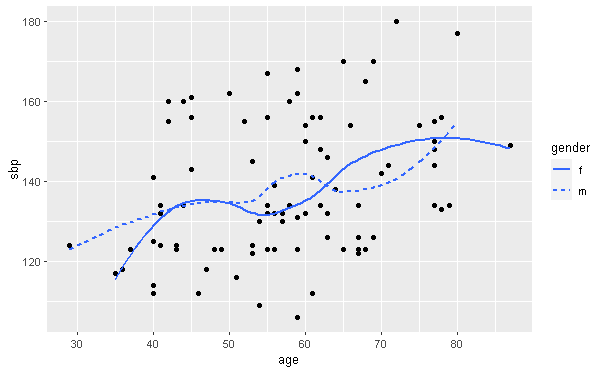

```r
library(ggplot2)
ggplot(data=Data,mapping=aes(x=age,y=sbp,linetype=gender))+
  geom_point()+
  geom_smooth(se=FALSE)
```

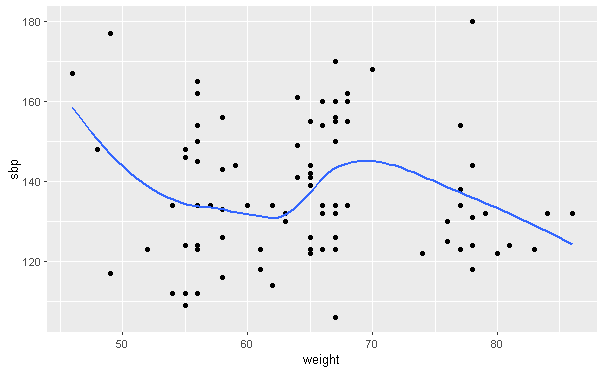

```r
ggplot(data=Data,mapping=aes(x=weight,y=sbp))+
  geom_point()+
  geom_smooth(se=FALSE)
```

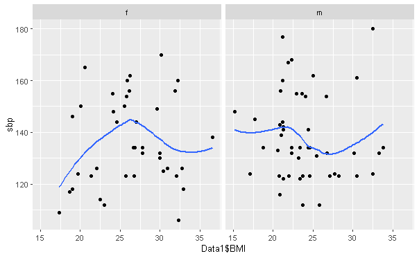

```r
ggplot(data=Data,mapping=aes(x=Data1$BMI,y=sbp))+
  geom_point()+
  geom_smooth(se=FALSE)+
  facet_wrap(~gender)+
  geom_smooth(se=FALSE)
```

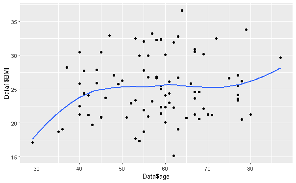

```r
ggplot(data=Data1,mapping=aes(x=Data$age,y=Data1$BMI))+
  geom_point()+
  geom_smooth(se=FALSE)
```

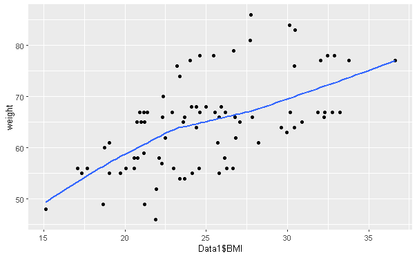

```r
ggplot(data=Data1,mapping=aes(x=Data1$BMI,y=weight))+
  geom_point()+
  geom_smooth(se=FALSE)
```

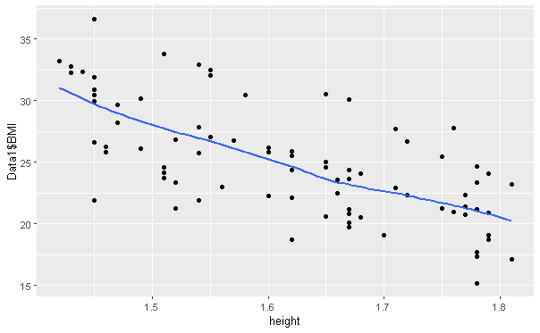

```r
ggplot(data=Data1,mapping=aes(x=height,y=Data1$BMI))+
  geom_point()+
  geom_smooth(se=FALSE)
```

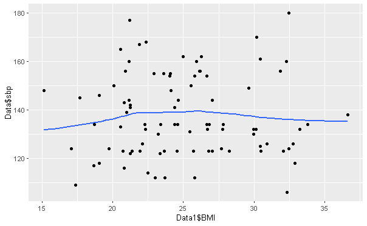

```r
ggplot(data=Data1,mapping=aes(x=Data1$BMI,y=Data$sbp))+
  geom_point()+
  geom_smooth(se=FALSE)
```

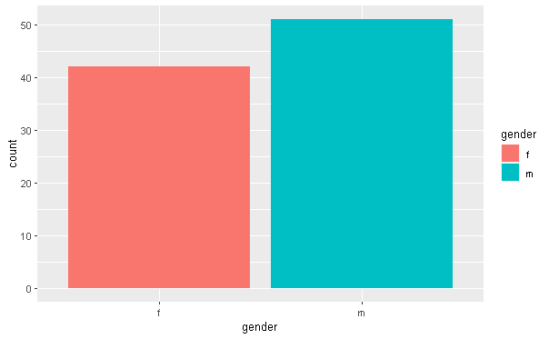

```r
ggplot(data=Data)+
  geom_bar(mapping=aes(x=gender,fill=gender))
```

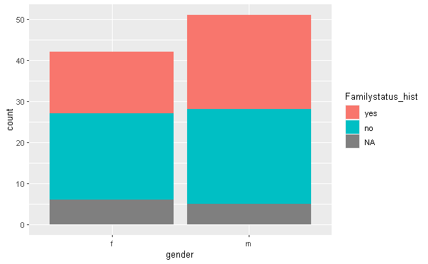

```r
ggplot(data=Data)+
  geom_bar(mapping=aes(x=gender,fill=Familystatus_hist))
```

10. Exploring the relationship between gender and smoking status H0:There is no association between gender and smoking status

[figure not shown]

```r
table1<-xtabs(~smoking_status+gender,data=Data)
barplot(as.matrix(table1),main="Gender by Smoking Status",col=c(2,4),
legend.text=c("non smoker","smoker"),beside=TRUE)
```

```r
TAB<-table(Data1$gender,smoking_status)

chisq.test(table(TAB),correct=T)
```

```
    Chi-squared test for given probabilities

data:  table(TAB)
X-squared = 0, df = 3, p-value = 1
```

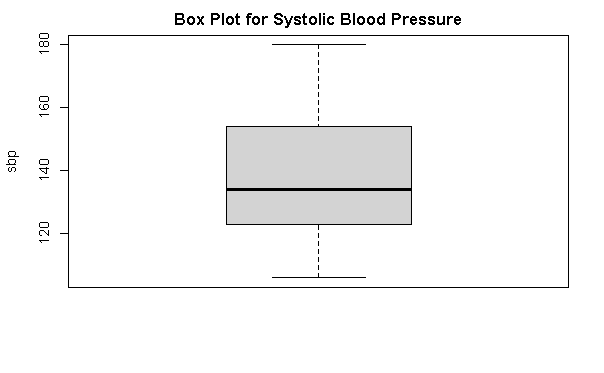

```r
boxplot(Data$sbp,main="Box Plot for Systolic Blood Pressure",ylab="sbp")
```

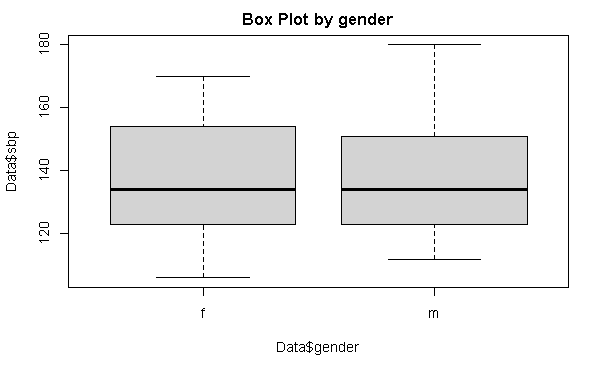

```r
boxplot(Data$sbp~Data$gender,main="Box Plot by gender")
```

```r
 Males=subset(Data,gender=="m")
Females=subset(Data,gender=="f")

mean(Males$sbp,na.rm=T)
```

```
[1] 138.2353
```

```r
mean(Females$sbp,na.rm=T)
```

```
[1] 137.1429
```

```r
t.test(Males$sbp,Females$sbp,alternative="two.sided",conf.level=0.95)
```

```
    Welch Two Sample t-test

data:  Males$sbp and Females$sbp
t = 0.30612, df = 87.61, p-value = 0.7602
alternative hypothesis: true difference in means is not equal to 0
95 percent confidence interval:
 -5.999998  8.184872
sample estimates:
mean of x mean of y
 138.2353  137.1429
```

- P>0.05,There is no association between gender and SBP
12. Exploring relationship between Smoking status and SBP H0:There is no association between SBP and smoking status

```r
mean(smokers$sbp,na.rm=T)
```

```
[1] 138
```

```r
mean(nonsmokers$sbp,na.rm=T)
```

```
[1] 137.5714
```

```r
var(Data$sbp[smoking_status=="yes"])
```

```
[1] 303.8889
```

```r
var(Data$sbp[smoking_status=="no"])
```

```
[1] 286.8312
```

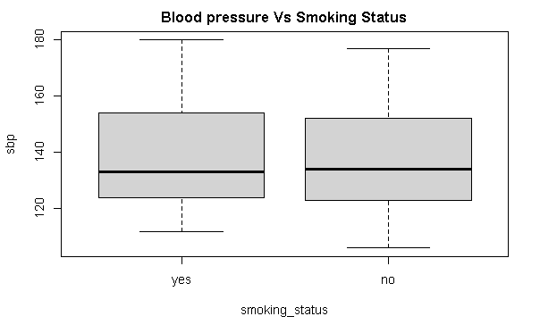

```r
boxplot(Data$sbp~smoking_status,ylab="sbp",main="Blood pressure Vs Smoking Status")
```

```r
t.test(smokers$sbp,nonsmokers$sbp,alternative="two.sided",conf.level=0.95)
```

```
    Welch Two Sample t-test

data:  smokers$sbp and nonsmokers$sbp
t = 0.11736, df = 75.646, p-value = 0.9069
alternative hypothesis: true difference in means is not equal to 0
95 percent confidence interval:
 -6.845048  7.702191
sample estimates:
mean of x mean of y
 138.0000  137.5714
```

# Conclusion: P> 0.05, There is no association between SBP and smoking status

13. Exploring relationship between Family history status and SBP Ho: There is no association between SBP and family history of disease

```r
fam_yes=subset(Data,Familystatus_hist=="yes")
fam_no=subset(Data,Familystatus_hist=="no")

mean(fam_yes$sbp,na.rm=T)
```

```
[1] 136.9474
```

```r
mean(fam_no$sbp,na.rm=T)
```

```
[1] 137.2727
```

```r
t.test(fam_yes$sbp,fam_no$sbp,alternative="two.sided",conf.level=0.95)
```

```
    Welch Two Sample t-test

data:  fam_yes$sbp and fam_no$sbp
t = -0.084211, df = 76.746, p-value = 0.9331
alternative hypothesis: true difference in means is not equal to 0
95 percent confidence interval:
 -8.019200  7.368482
sample estimates:
mean of x mean of y
 136.9474  137.2727
```

- Conclusion: P>0.05,There is no association between SBP and family history of disease
14. Exploring relationship between gender and Family history status Ho:There is no association between gender and family history of disease

[figure not shown]

```r
table2<-xtabs(~smoking_status+Familystatus_hist,data=Data)

barplot(as.matrix(table2),main="Family History by Smoking Status",col=c(5,12),
        legend.text=c("non smoker","smoker"),beside=TRUE)
```

```r
TAB2<-table(Data1$gender,Familystatus_hist)

chisq.test(table(TAB2),correct=T)
```

```
    Chi-squared test for given probabilities

data:  table(TAB2)
X-squared = 0.5, df = 2, p-value = 0.7788
```

- Conclusion:P>0.05, There is no association between gender and Family history of disease
15. Visualizing BMI by Smoking status

```r
plot(Data$sbp[smoking_status=="no"],Data1$BMI[smoking_status=="no"],
     main="plot",col=4,xlab ="BMI",ylab="sbp")
points(Data$sbp[smoking_status=="yes"],Data1$BMI[smoking_status=="yes"],col=2)
```

[figure not shown]

```r
legend(x=145,y=35,legend=c("nonsmoker","smoker"),col=c(4,2),pch=c(16,17),bty="n")
```

16. Visualizing age and smoking status according to SBP stratified groups

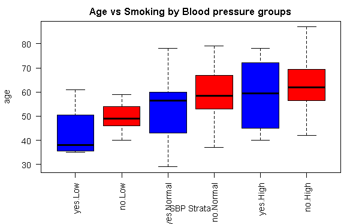

```r
boxplot(Data$age~smoking_status*SBPgroups,ylab="age",main="Age vs Smoking by Blood pressure groups",las=2,col=c("blue","red"),xlab="SBP Strata",pch=15,cex=0.8)
```

17. Exploring distribution of SBP using histogram

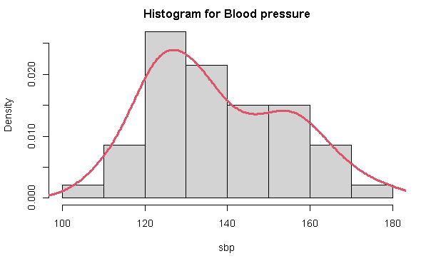

```r
hist(Data$sbp,freq=F,main="Histogram for Blood pressure",xlab="sbp")
lines(density(Data$sbp),col=2,lwd=3)
```

r)Generating Correlations between continous variables

```r
r<-c(Data$age,Data$sbp,Data1$BMI)
mat<-matrix(r,ncol = 3,nrow = 93)
result<-rcorr(mat)
result$r[result$n<5]<-0
result$r
```

```
          [,1]        [,2]        [,3]
[1,] 1.0000000 0.333883751 0.150213651
[2,] 0.3338838 1.000000000 0.004927067
[3,] 0.1502137 0.004927067 1.000000000
```

s)Fitting simple regression models

```r
plot(Data$age,Data$sbp,main="scatter plot",col=5)
text(x=35, y=175,adj=0,label="r=0.4",cex=2,font=4,)
```

[figure not shown]

```r
abline(lm(Data$sbp~ Data$age),col=2)
```

```r
model1<-lm(Data$sbp~Data$age)
model1
```

```
Call:
lm(formula = Data$sbp ~ Data$age)

Coefficients:
(Intercept)     Data$age
   110.8745       0.4679
```

```r
summary(model1)
```

```
Call:
lm(formula = Data$sbp ~ Data$age)

Residuals:
   Min     1Q Median     3Q    Max
-32.48 -13.25  -4.01  11.06  35.44

Coefficients:
            Estimate Std. Error t value Pr(>|t|)
(Intercept) 110.8745     8.2461  13.446  < 2e-16 ***
Data$age      0.4679     0.1400   3.342  0.00122 **
---
Signif. codes:  0 ‘***’ 0.001 ‘**’ 0.01 ‘*’ 0.05 ‘.’ 0.1 ‘ ’ 1

Residual standard error: 16.25 on 89 degrees of freedom
  (2 observations deleted due to missingness)
Multiple R-squared:  0.1115,    Adjusted R-squared:  0.1015
F-statistic: 11.17 on 1 and 89 DF,  p-value: 0.001219
```

```r
model1$coefficients
```

```
(Intercept)    Data$age
110.8744849   0.4678531
```

```r
model2<-lm(Data1$BMI~Data$age)
model2
```

```
Call:
lm(formula = Data1$BMI ~ Data$age)

Coefficients:
(Intercept)     Data$age
   21.84593      0.05613
```

```r
model2$coefficients
```

```
(Intercept)    Data$age
21.84593446  0.05612688
```

```r
summary(model2)
```

```
Call:
lm(formula = Data1$BMI ~ Data$age)

Residuals:
     Min       1Q   Median       3Q      Max
-10.1762  -3.5464  -0.6913   3.3574  11.1850

Coefficients:
            Estimate Std. Error t value Pr(>|t|)
(Intercept) 21.84593    2.38879   9.145 3.03e-14 ***
Data$age     0.05613    0.04031   1.393    0.167
---
Signif. codes:  0 ‘***’ 0.001 ‘**’ 0.01 ‘*’ 0.05 ‘.’ 0.1 ‘ ’ 1

Residual standard error: 4.577 on 84 degrees of freedom
  (7 observations deleted due to missingness)
Multiple R-squared:  0.02256,   Adjusted R-squared:  0.01093
F-statistic: 1.939 on 1 and 84 DF,  p-value: 0.1674
```

```r
MODEL1<-lm(Data$sbp~Data$age+Data1$BMI)
summary(MODEL1)
```

```
Call:
lm(formula = Data$sbp ~ Data$age + Data1$BMI)

Residuals:
    Min      1Q  Median      3Q     Max
-30.775 -11.903  -3.496  10.174  37.336

Coefficients:
            Estimate Std. Error t value Pr(>|t|)
(Intercept) 116.0080    11.9988   9.668 3.01e-15 ***
Data$age      0.4553     0.1450   3.141  0.00233 **
Data1$BMI    -0.1887     0.3880  -0.486  0.62801
---
Signif. codes:  0 ‘***’ 0.001 ‘**’ 0.01 ‘*’ 0.05 ‘.’ 0.1 ‘ ’ 1

Residual standard error: 16.27 on 83 degrees of freedom
  (7 observations deleted due to missingness)
Multiple R-squared:  0.1062,    Adjusted R-squared:  0.0847
F-statistic: 4.933 on 2 and 83 DF,  p-value: 0.009456
```

```r
MODEL2<-lm(Data$sbp~Data$age+Data1$BMI+Data$gender+Data$smoking_sta+Familystatus_hist)
summary(MODEL2)
```

```
Call:
lm(formula = Data$sbp ~ Data$age + Data1$BMI + Data$gender +
    Data$smoking_sta + Familystatus_hist)

Residuals:
    Min      1Q  Median      3Q     Max
-28.719 -11.358  -3.409   9.731  32.698

Coefficients:
                     Estimate Std. Error t value Pr(>|t|)
(Intercept)         116.26129   14.41509   8.065 1.52e-11 ***
Data$age              0.45382    0.15805   2.871  0.00542 **
Data1$BMI            -0.01824    0.44616  -0.041  0.96751
Data$genderm          2.82150    4.02875   0.700  0.48607
Data$smoking_sta     -3.86383    4.11425  -0.939  0.35094
Familystatus_histno  -0.82381    3.93227  -0.210  0.83468
---
Signif. codes:  0 ‘***’ 0.001 ‘**’ 0.01 ‘*’ 0.05 ‘.’ 0.1 ‘ ’ 1

Residual standard error: 16.73 on 69 degrees of freedom
  (18 observations deleted due to missingness)
Multiple R-squared:  0.1227,    Adjusted R-squared:  0.0591
F-statistic:  1.93 on 5 and 69 DF,  p-value: 0.1005
```